# Missing Data

# Missing Data

Data generated by people has missing values – this is an unfortunate truth. While shying away from the truth might someone’s idea of a good time, missing data provides us with some interesting issues to tackle.

## Why Is Missing Data Important

The vast majority of statistical techniques are not robust to missingness. Take our standard linear model (lm):

```r
library(dplyr)
library(magrittr)

testData = read.csv("missingSurvey.csv")

testData %>%
  lm(average_weekly_hours ~ EMP_Engagement_5, data = .) %>%
  summary()
```

```
##
## Call:
## lm(formula = average_weekly_hours ~ EMP_Engagement_5, data = .)
##
## Residuals:
##      Min       1Q   Median       3Q      Max
## -14.4551  -5.5699   0.2005   5.3153  31.4301
##
## Coefficients:
##                  Estimate Std. Error t value Pr(>|t|)
## (Intercept)       17.9143     0.2439   73.46   <2e-16 ***
## EMP_Engagement_5   2.8852     0.0913   31.60   <2e-16 ***
## ---
## Signif. codes:  0 '***' 0.001 '**' 0.01 '*' 0.05 '.' 0.1 ' ' 1
##
## Residual standard error: 7.031 on 13743 degrees of freedom
##   (1254 observations deleted due to missingness)
## Multiple R-squared:  0.06775,    Adjusted R-squared:  0.06768
## F-statistic: 998.7 on 1 and 13743 DF,  p-value: < 2.2e-16
```

Do you see any discrepancies? If we look at the number of rows within our data, we see a value of 14999 - a very decent sample for sure. If, however, we take a look at our degrees of freedom from our model output, we see that a considerable amount of rows were dropped (the output even gives us a message letting us know how many were dropped). A linear regression cannot use missing information, so the whole row gets dropped if any missingness exists within the variables being used. If an observation or dozen get(s) dropped out of a few hundred rows, we might not have too much to worry about. What about if more than half of the observations get dropped? It’s probably not a good thing.

## Types Of Missingness

When we talk about missing data, it is easy to assume that it is just missing: nothing more and nothing less. What if we knew why those were missing. Would that change your thoughts on missingness? What if you knew that certain people did not responsd to certain questions (for example, people who do not identify with any particular religion may leave a question about religious strength blank). Just thinking about such an example, would grouping that kind of missingness with someone who just skipped a question purely through omission make sense? You would likely say that they are different and you would be correct. Generally, we can think of three different types of missing values: missing completely at random, missing at random, and missing not at random.

Data missing completely at random (MCAR), is exactly how it sounds – the missing data is not related to any study variables and it is not related to any unknown process or parameter about the person generating the data. We can assume that MCAR data is not biased.

Data missing at random (MAR) is a bit different and little trickier. MAR data, despite the name, assumes that data is not really missing at random, but is instead fully explained by some other observed variable not related to the missing data.

Missing not at random (MNAR) just extends MAR to assume that the missing data is caused by the missing data.

### Determining Missingness Types

Determining which type of missingness is present within your data can be tricky. In the most ideal world, we would have the data to know whether it is MCAR or something else. I think you can see the circular nature that we are getting ourselves in!

There are, however, some methods that will let us test our missingness. The MissMech package will perform some tests that can help.

```r
library(MissMech)

library(dplyr)

mcarTest = TestMCARNormality(testData)

mcarTest
```

```
## Call:
## TestMCARNormality(data = testData)
##
## Number of Patterns:  7
##
## Total number of cases used in the analysis:  14999
##
##  Pattern(s) used:
##           EMP_Engagement_1   EMP_Engagement_2   EMP_Engagement_3
## group.1                  1                  1                  1
## group.2                  1                  1                  1
## group.3                  1                  1                  1
## group.4                  1                 NA                  1
## group.5                  1                  1                  1
## group.6                 NA                  1                  1
## group.7                  1                  1                 NA
##           EMP_Engagement_4   EMP_Engagement_5   average_weekly_hours
## group.1                  1                  1                     NA
## group.2                  1                  1                      1
## group.3                 NA                  1                      1
## group.4                  1                  1                      1
## group.5                  1                 NA                      1
## group.6                  1                  1                      1
## group.7                  1                  1                      1
##           Number of cases
## group.1               618
## group.2             11214
## group.3               635
## group.4               658
## group.5               636
## group.6               618
## group.7               620
##
##
##     Test of normality and Homoscedasticity:
##   -------------------------------------------
##
## Hawkins Test:
##
##     P-value for the Hawkins test of normality and homoscedasticity:  7.09661e-304
##
##     Either the test of multivariate normality or homoscedasticity (or both) is rejected.
##     Provided that normality can be assumed, the hypothesis of MCAR is
##     rejected at 0.05 significance level.
##
## Non-Parametric Test:
##
##     P-value for the non-parametric test of homoscedasticity:  1.413518e-08
##
##     Hypothesis of MCAR is rejected at  0.05 significance level.
##     The multivariate normality test is inconclusive.
```

Had our results been different, we would have gotten a message stating, “There is not sufficient evidence to reject normality or MCAR at 0.05 significance level.”.

The language here is important – notice that there was very little in the way of absolutes because we can never be 100% confident that our data is missing completely at random.

The TestMCARNormality function will only take numeric variables, so be sure to keep that in mind when using it.

If we can establish MCAR, then we can proceed with some imputation without fear of introducing a terrible amount of bias. If we cannot establish that our missing data was missing completely at random, then our multiply imputed data might have some issues.

## Imputation Methods

Many types of mean imputation exist: mean imputation, median imputation, among others. The central tendancy-based imputation methods are classical holdovers. In essence, they replace a missing value with the mean/median of the column.

Here is a brief demonstration of how this might work:

```r
testData %>%
  mutate(average_weekly_hours = ifelse(is.na(average_weekly_hours) == TRUE,
                                       mean(average_weekly_hours, na.rm = TRUE),
                                       average_weekly_hours),
         EMP_Engagement_5 = ifelse(is.na(EMP_Engagement_5),
                                   mean(EMP_Engagement_5, na.rm = TRUE),
                                   EMP_Engagement_5)) %>%
  lm(average_weekly_hours ~ EMP_Engagement_5, data = .) %>%
  summary()
```

```
##
## Call:
## lm(formula = average_weekly_hours ~ EMP_Engagement_5, data = .)
##
## Residuals:
##     Min      1Q  Median      3Q     Max
## -14.283  -5.516  -0.378   5.251  33.622
##
## Coefficients:
##                  Estimate Std. Error t value Pr(>|t|)
## (Intercept)       18.2144     0.2344   77.69   <2e-16 ***
## EMP_Engagement_5   2.7672     0.0879   31.48   <2e-16 ***
## ---
## Signif. codes:  0 '***' 0.001 '**' 0.01 '*' 0.05 '.' 0.1 ' ' 1
##
## Residual standard error: 6.912 on 14997 degrees of freedom
## Multiple R-squared:  0.06199,    Adjusted R-squared:  0.06193
## F-statistic: 991.1 on 1 and 14997 DF,  p-value: < 2.2e-16
```

Our missing values are fixed, so all is well. In reality, we are making a pretty big logical leap with assuming that those missing values would be the mean. It might not be the worst assumption that we could make (if we knew that this was the actual population average, it might be slightly more reasonable), but it is still tenuous.

When statistics were done on punchcards, this was probalby about the best that could be done. With greater computing power and more advanced statistical methods, we can get much better imputation values.

## Multiple Imputation

### mice

Multiple imputation takes those simple imputation techniques much further. If we are using multivariate imputations by chained equations (mice), then we are going through a lengthy process to estimate the missing values and using several imputed datasets for our models. Data imputed with mice will use predictions on every variable around the missing data to predict the value of the missing data.

We are only interested in imputing our variable with missingness, so we will specify the “cart” method (classification and regression trees) for our engagement questions and predictive mean matching for our hours worked. There are many options depending upon your exact needs (i.e., data types), so spend some time looking at the built in imputation methods in mice. The “cart” and “pmm” methods were used here purely for flexibility.

```r
library(mice)
imputedData = mice(testData, m = 10, maxit = 20,
                   method = c("cart", "cart", "cart",
                              "cart", "cart", "pmm"),
                   pred = quickpred(testData, minpuc = .2, mincor = .01),
                   print = FALSE)

imputedData
```

```
## Class: mids
## Number of multiple imputations:  10
## Imputation methods:
##     EMP_Engagement_1     EMP_Engagement_2     EMP_Engagement_3
##               "cart"               "cart"               "cart"
##     EMP_Engagement_4     EMP_Engagement_5 average_weekly_hours
##               "cart"               "cart"                "pmm"
## PredictorMatrix:
##                      EMP_Engagement_1 EMP_Engagement_2 EMP_Engagement_3
## EMP_Engagement_1                    0                0                0
## EMP_Engagement_2                    0                0                0
## EMP_Engagement_3                    0                0                0
## EMP_Engagement_4                    1                1                1
## EMP_Engagement_5                    1                1                0
## average_weekly_hours                1                0                1
##                      EMP_Engagement_4 EMP_Engagement_5
## EMP_Engagement_1                    0                0
## EMP_Engagement_2                    1                1
## EMP_Engagement_3                    1                0
## EMP_Engagement_4                    0                0
## EMP_Engagement_5                    0                0
## average_weekly_hours                0                1
##                      average_weekly_hours
## EMP_Engagement_1                        0
## EMP_Engagement_2                        1
## EMP_Engagement_3                        1
## EMP_Engagement_4                        1
## EMP_Engagement_5                        1
## average_weekly_hours                    0
```

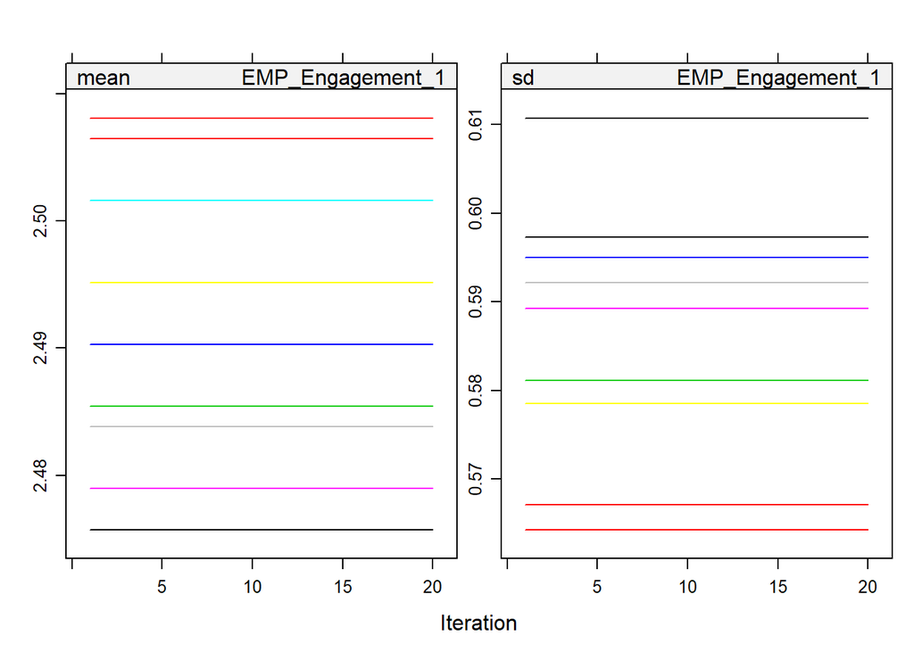

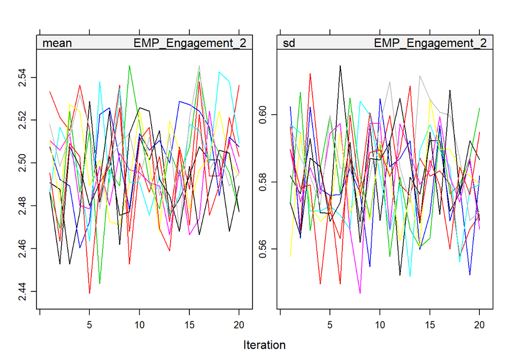

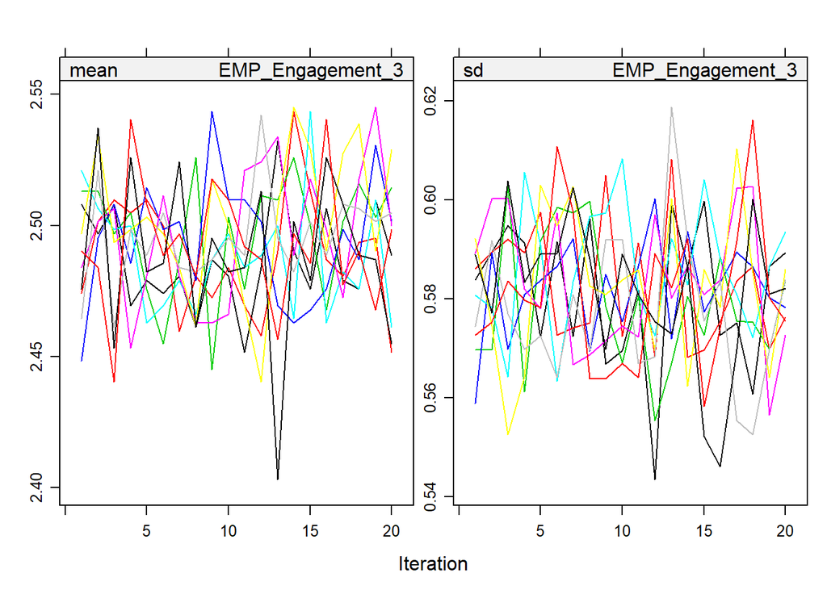

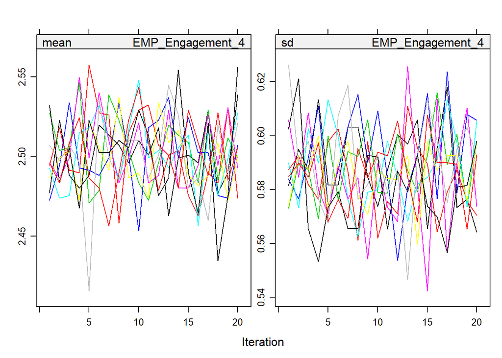

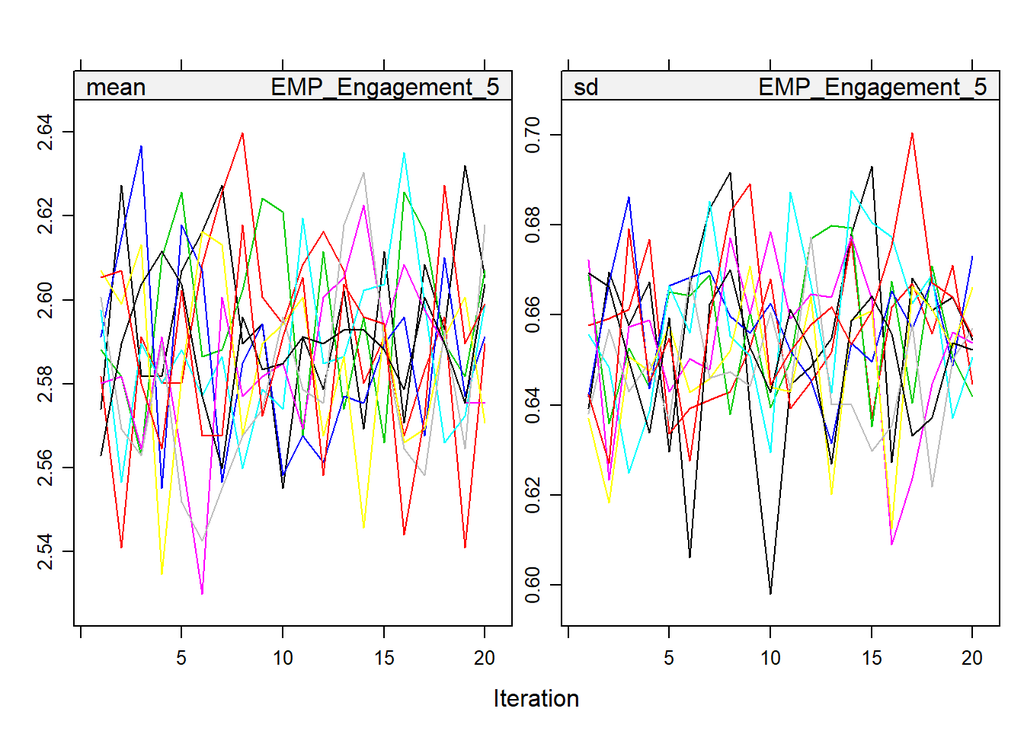

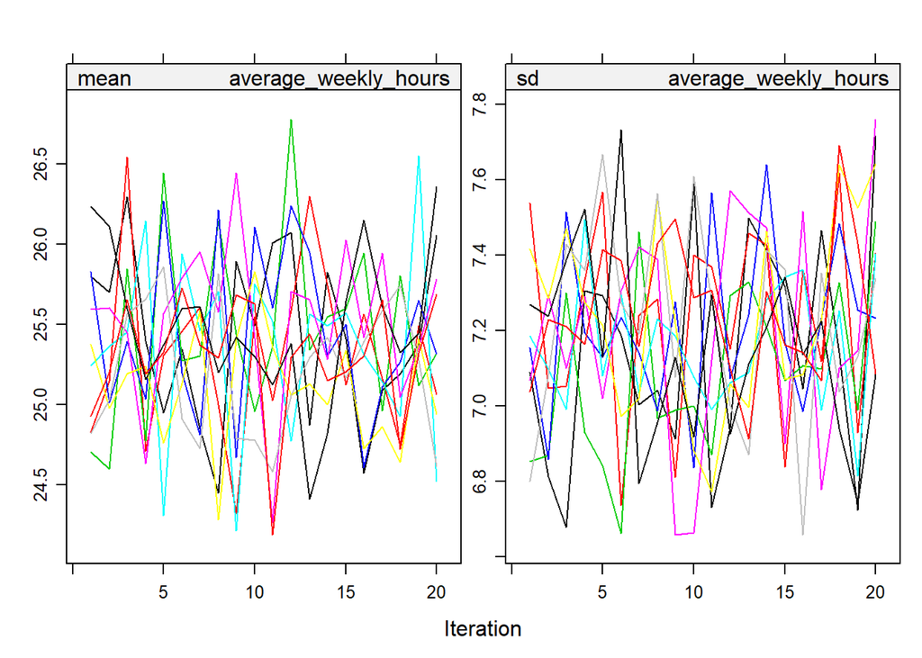

```r
plot(imputedData, layout = c(2, 1))
```

### On Markov Chains

The chained equations that we are dealing with in mice are very much akin to Markov Chain Monte Carlo methods.

Here is a conceptual example of markov chains! This example is adapted from Richard McElreath’s excellent book, *Statistical Rethinking*.

You manage 10 teams, named from 1 to 10. Each team name is proportional to the number of people on the team and each team is on a separate floor in the building.

You need to visit a team everyday, proportional to the number of people on the team (i.e., you would visit team 10 more often than team 1).

At the end of the day, you randomly select whether a proposed move will take you up a floor or down a floor.

After randomly selecting up or down, you grab a number of pens that is equal to the number of the current team (for team 10, you would grab 10 pens).

Next, you would grab a number of pencils corresponding to the proposed move (your randomly selected proposal would take you up a floor, so starting back at the bottom with team 1). So you would have 10 pens and 1 pencil.

If you have more pencils than pens, you will always move to the proposed floor.

If you have more pens than pencils, you set down a number of pens equal to the number of pencils and put them in a drawer.

You reach back into the drawer to randomly select a pen or a pencil.

Your selection decides where you go – pen is stay and pencil is go!

You should play with the following function (uncomment the line, play with starting values, etc.):

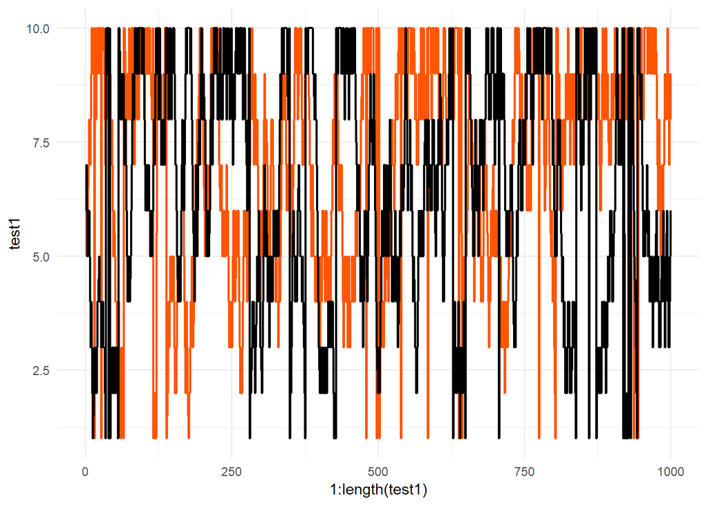

```r
markovSim = function(daysRun, startDay) {

  position = rep(0, daysRun)

  current = startDay

  for(i in 1:daysRun) {
    position[i] = current

    proposal = current + sample(c(-1, 1), size = 1)

    if(proposal < 1) proposal = 10

    if(proposal > 10) proposal = 1

    probabilityMove = proposal / current

    current = ifelse(runif(1) < probabilityMove, proposal, current)

    # print(paste(position[i], proposal, probabilityMove, current, sep = " -> "))
  }

  return(position)
}

test1 = markovSim(1000, 5)

test2 = markovSim(1000, 6)

library(ggplot2)

ggplot() +
  geom_line(data = as.data.frame(test1), aes(1:length(test1), test1),
            color = "#ff5500", size = .75) +
  geom_line(data = as.data.frame(test2), aes(1:length(test2), test2),
            color = "black", size = .75) +
  theme_minimal()
```

Does that plot look at all familiar – it sure does look like a *Pyrrharctia isabella* larvae to me. Beyond its similarity to woolybear caterpillar, this is a perfect illustration of a markov chain.

As fun as that was, let’s get back to the matter at hand.

Now, we have 10 imputed data sets that have been through 20 iterations that we can perform separate analyses on.

```r
fit1 = with(data = imputedData,
            exp = lm(average_weekly_hours ~ EMP_Engagement_5))
```

We can check on each individual imputed data set:

```r
summary(fit1)
```

```
## # A tibble: 20 x 5
##    term             estimate std.error statistic   p.value
##    <chr>               <dbl>     <dbl>     <dbl>     <dbl>
##  1 (Intercept)         17.9     0.235       76.4 0.
##  2 EMP_Engagement_5     2.89    0.0878      32.9 1.23e-228
##  3 (Intercept)         17.9     0.234       76.4 0.
##  4 EMP_Engagement_5     2.89    0.0877      32.9 7.62e-230
##  5 (Intercept)         17.9     0.234       76.2 0.
##  6 EMP_Engagement_5     2.91    0.0877      33.1 3.57e-232
##  7 (Intercept)         18.0     0.234       77.0 0.
##  8 EMP_Engagement_5     2.85    0.0875      32.6 1.24e-224
##  9 (Intercept)         17.8     0.234       76.0 0.
## 10 EMP_Engagement_5     2.91    0.0876      33.3 5.52e-234
## 11 (Intercept)         17.9     0.234       76.2 0.
## 12 EMP_Engagement_5     2.91    0.0878      33.1 5.27e-232
## 13 (Intercept)         17.8     0.234       76.0 0.
## 14 EMP_Engagement_5     2.93    0.0876      33.5 5.97e-237
## 15 (Intercept)         17.7     0.234       75.8 0.
## 16 EMP_Engagement_5     2.95    0.0875      33.7 1.02e-239
## 17 (Intercept)         17.9     0.234       76.5 0.
## 18 EMP_Engagement_5     2.91    0.0875      33.3 3.63e-234
## 19 (Intercept)         17.8     0.233       76.2 0.
## 20 EMP_Engagement_5     2.94    0.0874      33.7 5.26e-240
```

All of our coefficients are hoving around or slightly above our original coefficient, but our standard errors are uniformly smaller.

And we can then pool those results together:

```r
pooledFit = pool(fit1)

summary(pooledFit)
```

```
##                   estimate  std.error statistic       df p.value
## (Intercept)      17.847540 0.25054709  71.23427 531.0723       0
## EMP_Engagement_5  2.908382 0.09281962  31.33370 718.7926       0
```

How different are these pooled coefficients compared to our previous coefficients? The pooled are certainly a bit stronger, but not terribly so.

## Missing Or Sparse

On occasion you will see some data that looks like it has a lot of missingness. It might not truly be missing, it just might be sparse. Missing means that something was skipped (think about a survey question) and you have no idea what the value actually is. In sparse data, the observations have a zero value.

Sparsity comes up in a great many places, but the following example will hopefully help to make the point clearer. I shop on Amazon, but I have not bought everything there is to buy on Amazon. Not only have I not bought everything, I have not even seen every product on Amazon. If there were to be a matrix of every item that I have bought off of Amazon (all of those products get a 1) and everything I have not bought off Amazon (all of those products would get a 0), we would have very sparse data. In other words, Amazon actually knows what I have and have not bought.

On the other hand, let’s say that I just got a middle of the road Red Dragon keyboard RGB mechanical keyboard. Amazon knows that I bought it, so I would get a 1 in that column. However, I have not rated said keyboard; therefore, Amazon has no idea how much I actually like the keyboard. Essentially, there is a blank in the ratings column that cannot be assumed to be 0.